# Loan Data from Prosper (Exploratory Data Analysis)

#### 5. Corrolation Coefficient Matrix

To build on what we found in the correlation test above and provide some intuition on which variables have a strong positive or negative correlation (i.e. above 0.5, below -0.5), let’s plot the correlation matrix using Pearson correlation test

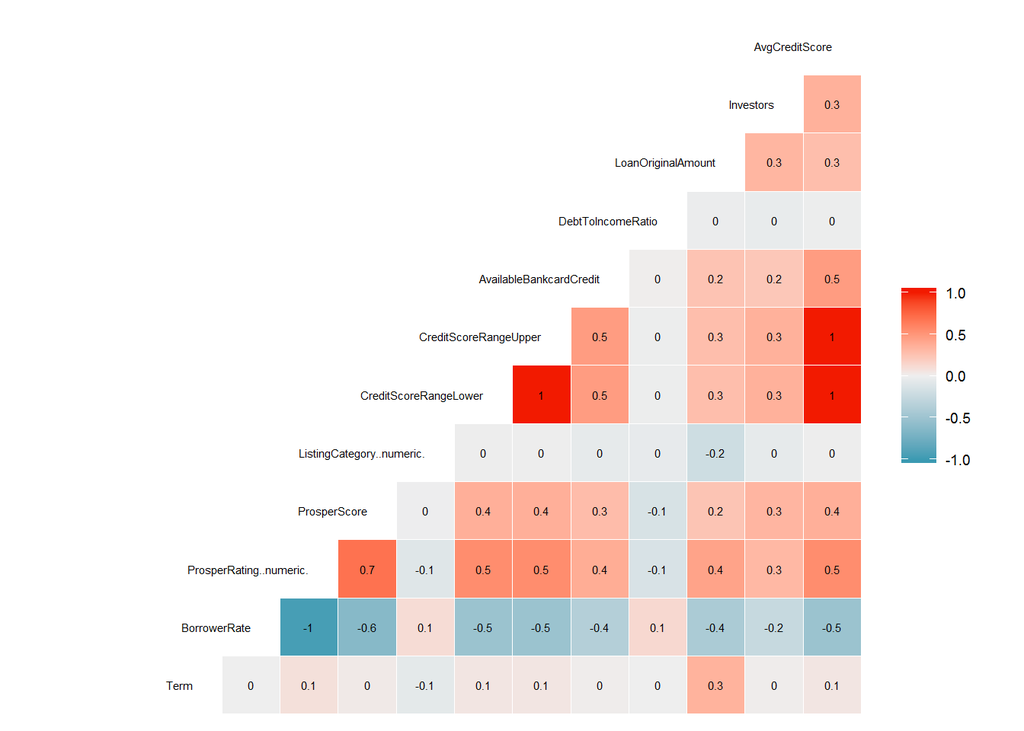

Looking at the matrix above, we notice the following:

- *Credit Score and Available Bank Card Credit*: we notice a fairly strong postive correlation (coeff: 0.5) between credit score and available bank card credit.
- *Prosper Score & Prosper Rating*: we notice a strong positive correlation (coeff: 0.7) between ProsperScore and ProsperRating which is expected.
  - *Credit Score & Prosper Rating*: we notice a strong positive correlation (coeff: 0.5) between credit score and Prosper Rating which is also expected.
  - *Prosper Score & Borrower Rate*: we notice a strong negative correlation (coeff: -0.6) between Prosper score and Borrower Rate which is expected.
  - *Credit Score & Borrower Rate*: we notice a farily strong negative correlation (coeff: -0.5) between Credit score and Borrower Rate which is expected.
  - *Prosper Rating & Borrower Rate*: we notice a strong negative correlation (coeff: -1) between Prosper Rating and Borrower Rate which is expected.

# Bivariate Analysis

### Summary:

In the bivariate analysis, we analyzed two types of relationships between variables:

1. **Categorical / Categorical**: in this section, I analyzed the relationship between Loan Delinquency and a number of variables and found the following:
   - *Loan Delinquency (by Loan Creation Year)*: the percentage of Good Standing loans has significantly increased in 2014 (99.93%) after reaching its lowest value (78.61%) in 2011.
   - *Loan Delinquency (by Term)*: the loans with 12 month term duation tend to perform better than loans with 36- and 60- month term duation;
   - *Loan Delinquency (by ProsperRating)*: the proportion of Good Standing loans increases as the ProsperRating increases.
   - *Loan Delinquency (by ProsperScore)*: the proportion of Good Standing loans increases as the ProsperRating increases, however, for loans with scores of 4 and 5, the proportion of *Delinquent* loans goes up, which leads us to think there might be another feature that could have a **stronger** correlation with loan Delinquency than the correlation between `ProsperScore` and loan Delinuency.
   - *Loan Delinquency (by Listing Category)*: the category *RV* has the highest proportion of Good Standing Loans of (96.15%), where in *Debt Consoliation*, the percentage of good standing loans is (92.35%).
2. **Categorical / Numerical**: in this section, we analyzed how the values of numerical variables (mainly: Interest Rate and Original Loan Amount) are distributed when broken down by specific categorical variables, as follows:
   - *Borrower Rate (by Loan Delinquency)*: we noticed the distribution of the BorrowerRate for Good standing loans experiances more fluctuations than for Delinquent loans; we also found that the count of both Good standing and Delinquent loans peaks at BorrowRate = 0.32 or (32%).
   - *Debt-To-InCome Ratio (by Loan Delinquency)*: DebtToIncomeRatio has a right-skewed distribution across both Delinquent and Good standing loans.
   - *Interest Rate (by State)*: Alabama (AL) has the highest average interest rate of (20.9%) where District of Columbia (DC) has the lowest average interest rate of around (17.7%); We also found that California (CA), which has the highest loan proportion has an average interest rate of (19%).
   - *Interest Rate (by Listing Category)*: here we noticed that *Not Available* has the highest average interest rate of 23.9%, where *Boat* has the lowest average interest rate of 17.4%.
   - *Interest Rate (by Employment Status)*: the category Not employed has the highest average interest rate of 26%, where the category Employed has the lowest average interest rate of 19.3%.
3. **Numerical / Numerical**:
   - *Interest Rate vs. Debt-To-Income Ratio*: Unexpectedly, the data showed a very weak or no corrolation between the two variables as someone would expect borrowers with higher DebtToIncomeRatio to be charged higher interest rates, however, after applying Pearson’s corrolation test, the returned corrolation co-efficient was (0.06).
   - *Interest Rate Vs. LoanOriginalAmount*: here we found a relatively negative correlation between the original loan amount and the interest rate with a corrolation co-efficient of (-0.33).

# Multivariate Plots Section

In this section, I will continue to focus on interest rate, loan delinquency but I will add additional variables, such as prosperScore, loan original amount and debtToIncomeRatio and build on the analysis performed in the first two sections.

#### 1. Average Interest Rate by Average Credit Score & Delinquency

In this section, I will analyze the relationship between the average interest rate and the average credit score (the custom variable we created) and show how this relationship may vary depending on loan status (Good Standing vs. Delinquent).

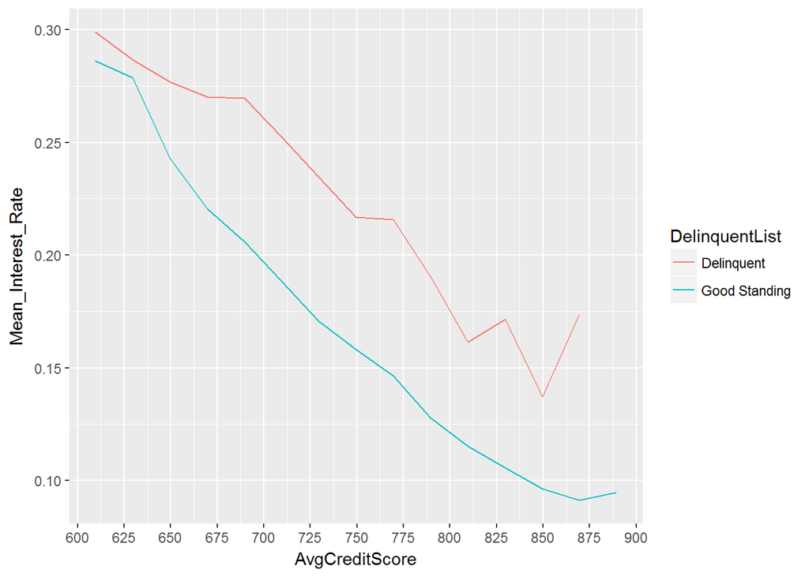

Looking at the output above, we notice that for both *Good Standing* and *Delinquent* loans, there is a negative correlation between the mean interest rate and the borrower’s average credit score, however, *Good Standing* loans show a steady decrease in the mean interest rate as the average credit score goes up, where in *Delinquent* loans, we see more fluctuations especially for borrowers with high credit scores, as we can see, as the average credit score goes above 850, the mean interest rate for *Delinquent* loans jumps up which may seem unusual. This interesting observation may be an area for further analysis.

#### 2. Interest rate by Prosper Score & Loan Delinquency

As we have seen in the Bivariate Analysis (plot 5: Loan Delinquency vs. ProsperScore), there is a negative correlation between ProsperRating and loan Delinquency, however, this correlation unexpectedly changed to positive for loans with Prosper socres of 3, 4 and 5. In this section, I will analyze the relationship between Loan Delinquency, ProposerScore and a number of variables, in an attempt to find an explanation for this observation.

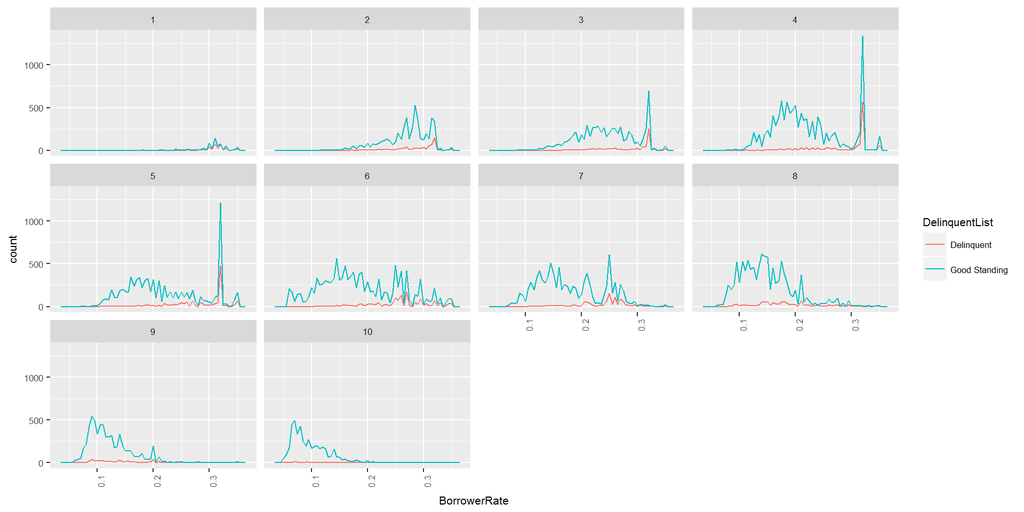

Looking at the output above, for loans with the scores 3, 4, and 5, the count of both good standing and delinquent loans experiences a significant spike at 0.3177 and 0.3199; we saw this observation before in the bivariate section; to take things further, let’s isolate the loans with a ProsperScore of 3, 4, or 5, and a BorrowerRate of 0.3177 and 0.3199

```
## [1] 4448
```

Looking at the output above, we notice there are 4,448 loans that fit our criteria. Now, let’s plot the correlation matrix for these loans:

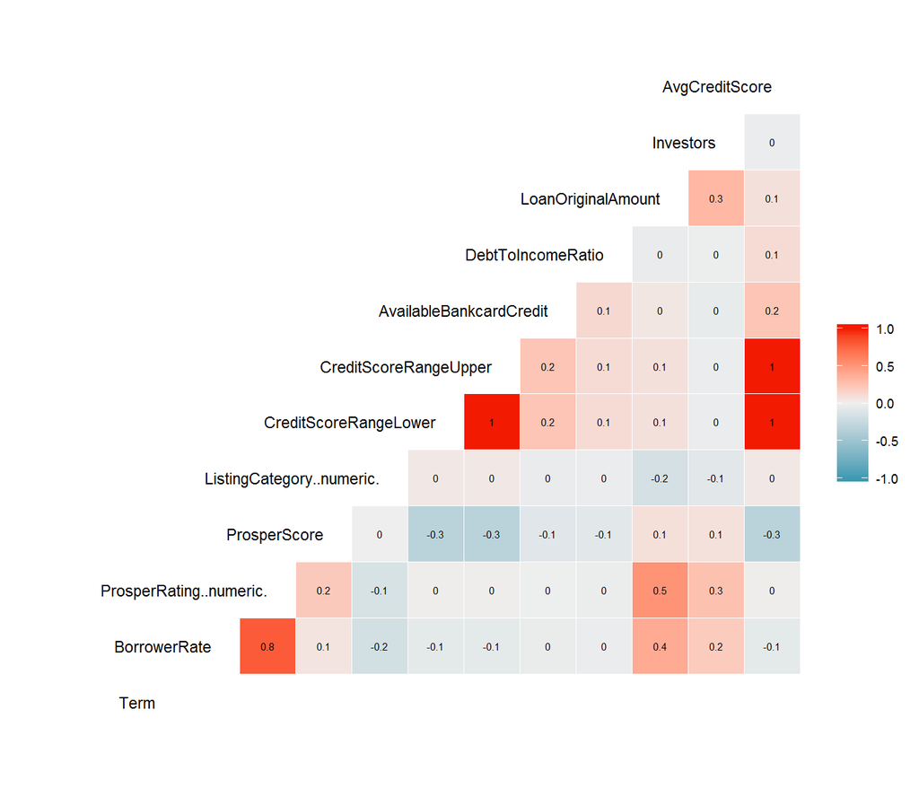

#### 3. DebtToIncomeRatio by Average Credit Score and Loan Status

In this section, I will analyze the relationship between average DebtToIncome Ratio and Credit Score based on loan status

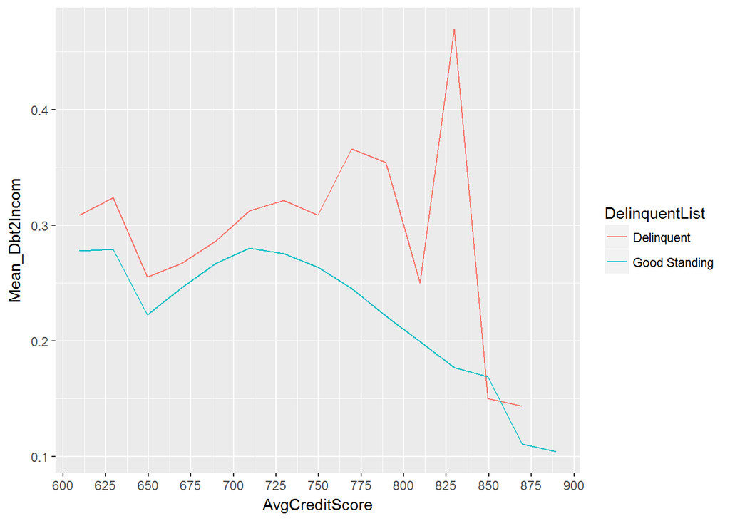

Looking at the plot above, we notice the type relationship between Average DebtToIncomeRation and average Credit score varies based on the credit score range. For borrowers with credit scores between 600 - 750, we see a fairly positive correlation between Debt2Income and Credit score, however, as the credit score goes above 750 we notice a negative correlation for the most part. We also notice that the mean DebtToIncome Ratio spikes above 0.45 for the credit scores between 825 and 835 and then drops signficiantly below 0.15

#### 4. Average Loan Original Amount by Average Credit Score, Delinquency and Income Range

In this section, I will analyze the relationship between average Loan Original Amount and Credit Score and how this relationship may vary depending on the income range and loan status.

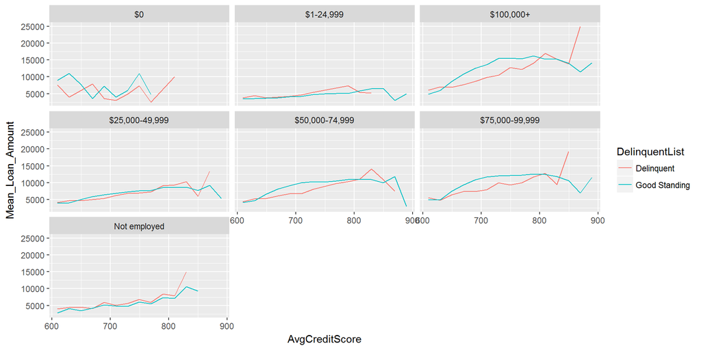

Looking at the plot grid above, while different income levels show differet behaviour, we may fairly say that for the most part, there may be a weak positive corroaltion between the average loan amount and the average credit score for both good standing and delinquent loans with few deviations, for example: in the income range 50K-75K, we noticed the average loan amount dropped significantly for borrowers with a credit score of 830 and above. On the other hand, for borrowers with an Income Range 100K+, the average loan amount spikes up especially for those with Delinquent loans.

# Multivariate Analysis

### Talk about some of the relationships you observed in this part of the investigation. Were there features that strengthened each other in terms of looking at your feature(s) of interest?

In this section, I will zoom in on two main variables: loan delinquency (loan status) and interest rate by exploring the following relationships:

1. Average Interest Rate by Average Credit Score & Delinquency:

Here I summarized the data to find out how the average interest rate varies depending on the average credit score by loan status. This is a common aspect to look at when applying for loans or credit cards and the goal here is to see if Delinquent loans have a different behaviour from good standing loans, and as expected, there is negative correlation between credit score and interest rate. In other words, higher credit score means lower interest rate. However, for delinquent loans, I observed some fluctuations and unusual behaviour where the interest rate increased as the credit score went above 850 which. This is area to be considered for further investigation.

2. Interest rate by Prosper Score & Loan Delinquency:

In this section, I tried to find an explanation of the observation I found in the Bivariate Analysis section where the proportion delinquent loans increased as the PropserScore increased from 3 to 5. By isolating the loans with these scores 3,4,5 and ploting the correlation matrix, I wasn’t able to identify any clear relationship between the ProsperScore and the variables, however, I found that for loans with the scores 3, 4, and 5, the count of both good standing and delinquent loans experiences a significant spike at interest rates 0.3177 and 0.3199.

3. DebtToIncomeRatio by Average Credit Score and Loan Status

Here I found that for borrowers with credit scores between 600 - 750, we see a fairly positive correlation between Debt2Income and Credit score, however, as the credit score goes above 750 we notice a negative correlation for the most part. I also found that the mean DebtToIncome Ratio spikes above 0.45 for the credit scores between 825 and 835 and then drops signficiantly below 0.15.

4. Average Loan Original Amount by Average Credit Score, Delinquency and Income Range

In this analysis, we found a weak positive corroaltion between the average loan amount and the average credit score for both good standing and delinquent loans with few deviations, for example: in the income range 50K-75K, we noticed the average loan amount dropped significantly for borrowers with a credit score of 830 and above. On the other hand, for borrowers with an Income Range 100K+, the average loan amount spikes up especially for those with Delinquent loans.

### Were there any interesting or surprising interactions between features?

For the most part, all the observations found are consistent with our general understanding of the loan process. However, as I mentioned above, there is some unusual behaviour for the delinquent loans that may be interesting for further analysis. Please refer to the answer of the question above for more information.

# Final Plots and Summary

### Plot One: Borrower Rate Distribution (by Loan Status)

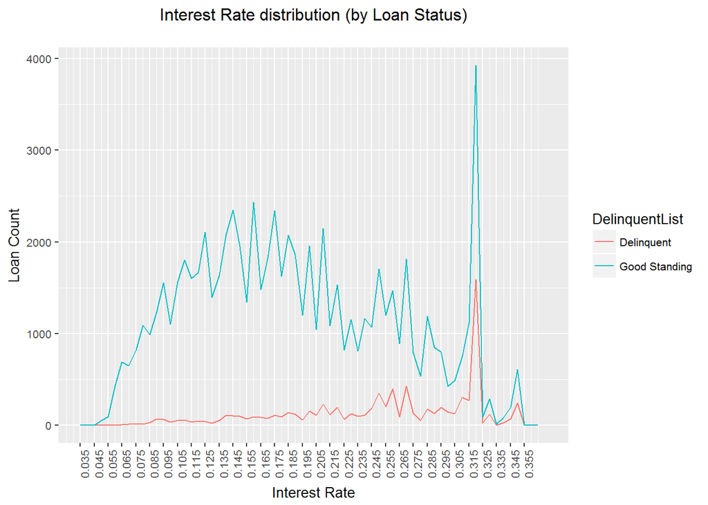

### Description One

In the plot above, we found that the distribution of the `BorrowerRate` for *Good standing* loans experiences more fluctuations than *Delinquent* loans; we also notice the count of both *Good standing* and *Delinquent* loans experiances a significant peak at BorrowRate = 0.31799.

### Plot Two: Interest Rate vs LoanOriginalAmount

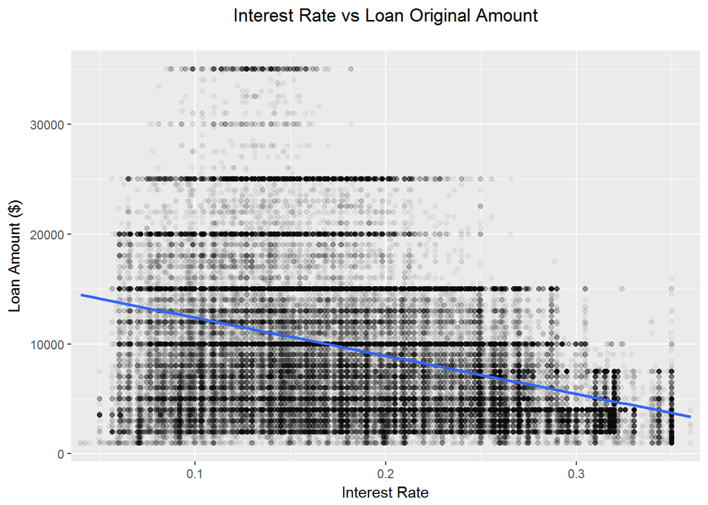

### Description Two

In this plot, we observed a negative correlation between the original loan amount and the interest rate which makes sense as larger loan amounts are more likely to receive lower interest rates than smaller loan amounts; to confirm our observation, I performed a correlation test and got (-0.33) which indicates a weak negative correlation between the two variables.

### Plot Three: Average Interest Rate Vs Average Credit Score (by Loan Status)

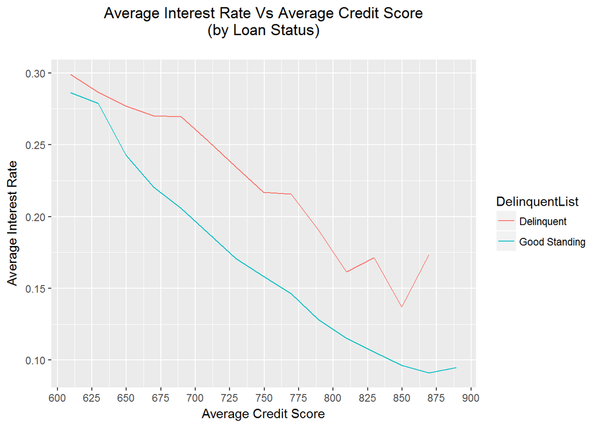

### Description Three

Looking at the output above, we notice that for both *Good Standing* and *Delinquent* loans, there is a negative correlation between the mean interest rate and the borrower’s average credit score, however, *Good Standing* loans show a steady decrease in the mean interest rate as the average credit score goes up, where in *Delinquent* loans, we see more fluctuations especially for borrowers with high credit scores, as we can see, as the average credit score goes above 850, the mean interest rate for *Delinquent* loans jumps up which may seem unusual.

# Reflection

The analysis above aimed at exploring the Prosper Loan dataset. I focused 2 key variables: Interest Rate and Loan Delinquency. The purpose of the analysis was to provide a preliminary guidance to help borrowers and investors make informative decisions. The majority of the observations is consistent with the general understanding of the loan process. There was a number of unusual observations that were pointed out in the analysis that could be investigated further. There was no major chanllenges in performing the analysis. Some of the minor challenges faced: - missing values - duplicated values - erroneous values - Lack of detailed definitions for a number of variables.

Throughtout the analysis, I created a number of variables and functions to facilitate the analysis.

Beside the comments above, some of the areas for future improvement may include:

### References

https://en.wikipedia.org/wiki/Prosper_Marketplace https://www.prosper.com/ https://www.investopedia.com/ask/answers/09/difference-between-yields-and-interest-rate.asp https://www.investopedia.com/ask/answers/062315/what-are-differences-between-delinquency-and-default.asp https://www.investopedia.com/terms/r/revolving-account.asp https://www.investopedia.com/terms/t/trade-line.asp https://en.wikipedia.org/wiki/Pearson_correlation_coefficient